# Final_Draft

```python
import pandas as pd
import numpy as np
from sklearn.tree import DecisionTreeClassifier
from sklearn.model_selection import train_test_split
from sklearn.metrics import accuracy_score, roc_auc_score
from sklearn.model_selection import GridSearchCV
from sklearn.metrics import confusion_matrix, accuracy_score
from sklearn import tree
import matplotlib.pyplot as plt
import seaborn as sns
from sklearn.model_selection import cross_val_score
from sklearn.metrics import classification_report, confusion_matrix
from sklearn.model_selection import RandomizedSearchCV
from sklearn.preprocessing import MinMaxScaler
#!pip install holidays
import holidays
import plotly.express as px
from imblearn.over_sampling import SMOTE
from sklearn.metrics import roc_curve
pd.set_option("max_rows", None)
pd.set_option('display.max_columns', None)
from numpy import mean
from numpy import std
from sklearn.datasets import make_classification
from sklearn.model_selection import cross_val_score
from sklearn.model_selection import RepeatedStratifiedKFold
from xgboost import XGBClassifier
from matplotlib import pyplot
```

### The data set is first downloaded, to perform initial analysis on the subject at concern- which are flight cancellations

```python
# we first import the data frame
df = pd.read_csv('flights_2008.csv')
```

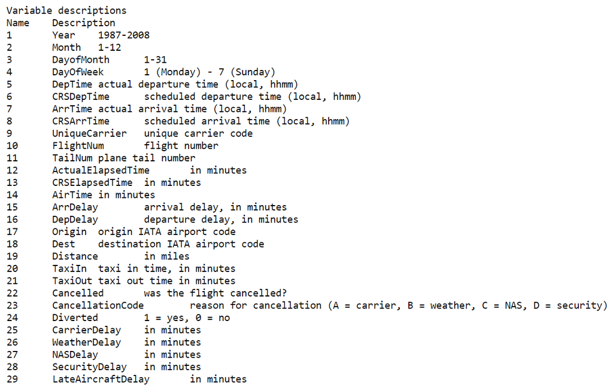

```python
#Screenshot 2021-12-13 103023.png
from IPython.display import display, Image
display(Image(filename='Screenshot 2021-12-13 103023.png'))
```

```python
df.head()
```

|  | Unnamed: 0 | Year | Month | DayofMonth | DayOfWeek | DepTime | CRSDepTime | ArrTime | CRSArrTime | UniqueCarrier | FlightNum | TailNum | ActualElapsedTime | CRSElapsedTime | AirTime | ArrDelay | DepDelay | Origin | Dest | Distance | TaxiIn | TaxiOut | Cancelled | CancellationCode | Diverted | CarrierDelay | WeatherDelay | NASDelay | SecurityDelay | … |
| --- | --- | --- | --- | --- | --- | --- | --- | --- | --- | --- | --- | --- | --- | --- | --- | --- | --- | --- | --- | --- | --- | --- | --- | --- | --- | --- | --- | --- | --- | --- |
| 0 | 0 | 2008 | 1 | 3 | 4 | 2003.0 | 1955 | 2211.0 | 2225 | WN | 335 | N712SW | 128.0 | 150.0 | 116.0 | -14.0 | 8.0 | IAD | TPA | 810 | 4.0 | 8.0 | 0 | N | 0 | NaN | NaN | NaN | NaN | … |
| 1 | 1 | 2008 | 1 | 3 | 4 | 754.0 | 735 | 1002.0 | 1000 | WN | 3231 | N772SW | 128.0 | 145.0 | 113.0 | 2.0 | 19.0 | IAD | TPA | 810 | 5.0 | 10.0 | 0 | N | 0 | NaN | NaN | NaN | NaN | … |
| 2 | 2 | 2008 | 1 | 3 | 4 | 628.0 | 620 | 804.0 | 750 | WN | 448 | N428WN | 96.0 | 90.0 | 76.0 | 14.0 | 8.0 | IND | BWI | 515 | 3.0 | 17.0 | 0 | N | 0 | NaN | NaN | NaN | NaN | … |
| 3 | 4 | 2008 | 1 | 3 | 4 | 1829.0 | 1755 | 1959.0 | 1925 | WN | 3920 | N464WN | 90.0 | 90.0 | 77.0 | 34.0 | 34.0 | IND | BWI | 515 | 3.0 | 10.0 | 0 | N | 0 | 2.0 | 0.0 | 0.0 | 0.0 | … |
| 4 | 5 | 2008 | 1 | 3 | 4 | 1940.0 | 1915 | 2121.0 | 2110 | WN | 378 | N726SW | 101.0 | 115.0 | 87.0 | 11.0 | 25.0 | IND | JAX | 688 | 4.0 | 10.0 | 0 | N | 0 | NaN | NaN | NaN | NaN | … |

```python
# defining all the functions here
def filter_airports(df,name):
    airport_cancelled = pd.DataFrame(df.groupby(name)['Cancelled'].sum()).reset_index()
    airport_count = pd.DataFrame(df[name].value_counts()).reset_index()
    airport_count.columns = [name, 'Count']
    airport_cancelled_count = pd.merge(airport_cancelled, airport_count, on = name )
    airport_cancelled_count=airport_cancelled_count.sort_values('Cancelled', ascending=False)
    list_of_airport = airport_cancelled_count[name].to_list()
    return(list_of_airport)


# function to evaluate a decision tree model
def evaluate_model(dt_classifier):
    print("Train Accuracy :", accuracy_score(Y_train, dt_classifier.predict(X_train)))
    print("Train Confusion Matrix:")
    confusion(Y_train,dt_classifier.predict(X_train))
    print('AUC:',roc_auc_score(Y_train,dt_classifier.predict(X_train)))
    print("-"*50)
    print("Test Accuracy :", accuracy_score(Y_test, dt_classifier.predict(X_test)))
    print("Test Confusion Matrix:")
    confusion(Y_test, dt_classifier.predict(X_test))
    print('AUC:',roc_auc_score(Y_test,dt_classifier.predict(X_test)))
    print(classification_report(Y_test,dt_classifier.predict(X_test)))


# function to plot confusion matrices for all the classification problems
def confusion(Y,X):
    cf_matrix = confusion_matrix(Y,X)
    group_names = ['True Neg','False Pos','False Neg','True Pos']
    group_counts = ["{0:0.0f}".format(value) for value in cf_matrix.flatten()]
    group_percentages = ["{0:.2%}".format(value) for value in cf_matrix.flatten()/np.sum(cf_matrix)]
    labels = [f"{v1}\n{v2}\n{v3}" for v1, v2, v3 in zip(group_names,group_counts,group_percentages)]
    labels = np.asarray(labels).reshape(2,2)
    sns.heatmap(cf_matrix, annot=labels, fmt='', cmap='Blues')
    plt.show()


# plotting the decision tree
def get_dt_graph(dt_classifier):
    fig = plt.figure(figsize=(30,20))
    _ = tree.plot_tree(dt_classifier,
                       feature_names=X_train.columns,
                       class_names=['Not Cancelled', "Cancelled"],
                       filled=True)

# converting time to hour
def hour_convert(data,column):
    data[column] = data[column].div(100).round(2)#getting only the hours
    data[column] = data[column].astype('str')
    split_data = df[column].apply(lambda x:x.split(".")[0])
    df[column] = split_data



def draw_roc( actual, probs ):
    fpr, tpr, thresholds = metrics.roc_curve( actual, probs,drop_intermediate = False )
    auc_score = metrics.roc_auc_score( actual, probs )
    plt.figure(figsize=(5, 5))
    plt.plot( fpr, tpr, label='ROC curve (area = %0.2f)' % auc_score )
    plt.plot([0, 1], [0, 1], 'k--')
    plt.xlim([0.0, 1.0])
    plt.ylim([0.0, 1.05])
    plt.xlabel('False Positive Rate or [1 - True Negative Rate]')
    plt.ylabel('True Positive Rate')
    plt.title('Receiver operating characteristic example')
    plt.legend(loc="lower right")
    plt.show()
    return None
```

```python
hour_convert(df,'CRSDepTime')# converting departure time to hour
```

```python
hour_convert(df,'CRSArrTime')# converting arrival time to hour
```

```python
df=df.rename(columns={"DayOfWeek": "Day"})
df['Date'] = pd.to_datetime(df[['Year','Month', 'Day']])
```

#### To add more definition to the data, so that the models can better interpret it, another feature is added of holidays, from the holidays library we get the list of holidays and a seperate column is created based on that

```python
us_holidays = holidays.US()
df['Holiday']=[1 if i in us_holidays else 0 for i in df['Date']]
```

```python
df['Holiday'].value_counts()
```

```
0    1864288
1      72470
Name: Holiday, dtype: int64
```

```python
# we filter the data frame according to flights that are not diverted
df_No_Diverted = df[df.Diverted==0]
```

```python
df_Delay = df_No_Diverted[df_No_Diverted.Cancelled==0]# creating the raw data for delays
```

```python
df_Delay.shape
```

```
(1928371, 32)
```

```python
df_Cleaned=df_No_Diverted
```

```python
# we drop columns which are results of cancellations not the factors effecting cancellations for a particular route
df_Cleaned.drop(['Unnamed: 0','Date','Year','ArrTime','DayofMonth','DepDelay','ActualElapsedTime','AirTime','ArrDelay','TaxiIn','TaxiOut','CancellationCode','Diverted','CarrierDelay','WeatherDelay','NASDelay','SecurityDelay','LateAircraftDelay','FlightNum','TailNum','DepTime','Dest'], axis =1, inplace=True)
```

```python
df_Cancelled = df_No_Diverted[df_No_Diverted.Cancelled==1]
```

#### According to our business case, we now need to see which are the origins from which maximum flights take off and at the same time, we need to segregate the origins and rank them according to most cancellation prone origins. This will help us to narrow down our data to the most contributing set.

#### Similarly we will also look for the airlines, which are most frequent carriers and are prone to maximum cancellations. We will then select those particular airlines which are contributing the most

```python
list_of_origins = filter_airports(df_Cleaned,'Origin')
```

```python
# selecting the top
org_list = ['ORD', 'IAH', 'DEN', 'ATL', 'DTW', 'DFW', 'LAX', 'SLC', 'BOS','MSP']#, 'SEA', 'LAS', 'EWR', 'JFK', 'LGA', 'CLT', 'MKE', 'CVG']
df_selected_origins = df_Cleaned[df_Cleaned['Origin'].isin (org_list)]
```

```python
# We now will try to focus on some airlines alone to drive a business perspective on restricted airlines
list_of_airlines = filter_airports(df_selected_origins,'UniqueCarrier')
print(list_of_airlines)
```

```
['MQ', 'OO', '9E', 'YV', 'XE', 'UA', 'CO', 'AA', 'EV', 'DL', 'NW', 'US', 'FL', 'B6', 'OH', 'F9', 'WN', 'AS', 'HA']
```

```python
airlines=['MQ', 'OO', 'YV', 'XE', 'UA', 'CO']# Taking top 6
df_selected = df_selected_origins[df_selected_origins['UniqueCarrier'].isin (airlines)]
```

```python
df_selected.shape
```

```
(282408, 10)
```

```python
df_selected['Cancelled'].value_counts()
```

```
0    282189
1       219
Name: Cancelled, dtype: int64
```

```python
# due to multipcolinearity, we will drop CRSElapsedTime
df_selected.drop('CRSElapsedTime',axis=1,inplace=True)
```

```python
# we are here converting all the categorical columns to dummies
df = pd.get_dummies(df_selected, columns=['Month','Day','UniqueCarrier','Origin','CRSDepTime','CRSArrTime'],drop_first=True)
```

```python
# y = df.pop('diagnosis').to_frame()
# X = df
Y = df['Cancelled']
X = df.drop(['Cancelled'],axis=1)
```

```python
X_train, X_test, Y_train, Y_test = train_test_split(
   X, Y, stratify = Y, test_size = 0.3)
```

### Min-Max scaling to reduce the continuous variables, from a range to 0 and 1

```python
ss = MinMaxScaler()
normalized_data = ss.fit_transform(np.array(X_train['Distance']).reshape(-1, 1))
X_train['Distance'] = normalized_data
```

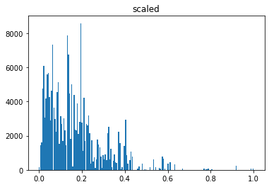

```python
plt.hist(x=X_train['Distance'], bins='auto', rwidth=0.95)
plt.title('scaled')
```

```python
# let us now prepare the test set of the dataframe
normalized_data = ss.transform(np.array(X_test['Distance']).reshape(-1, 1))
X_test['Distance'] = normalized_data
plt.hist(x=X_test['Distance'], bins='auto', rwidth=0.85)
plt.title('scaled')
```

[output not shown]

### Removing Imbalance in the dataset (Train)

```python
#we see an imbalance here, so we need to implement smote to neutralize this
Y_train.value_counts()
```

```
0    197532
1       153
Name: Cancelled, dtype: int64
```

```python
# we observe a high imbalance in the data set which leads us to do SMOTE, to balance the predicted outcomes, to avoid bias
oversample = SMOTE()
X_train, Y_train = oversample.fit_resample(X_train, Y_train)
```

```python
#the data is now balanced and prepared for prediction
Y_train.value_counts()
```

```
0    197532
1    197532
Name: Cancelled, dtype: int64
```

## ----------------------------------------------------------------------------------------------------------------------------------

# Classification Modeling Techniques (Cancellation)

### 1.Decision Tree 2.Random Forest Classifier 3. XGBoost 4.Support Vector Machine

### Decision Tree Classification

#### Decision trees can be used for classification as well as regression problems. The name itself suggests that it uses a flowchart like a tree structure to show the predictions that result from a series of feature-based splits. It starts with a root node and ends with a decision made by leaves. We will select a few parameters and assign a range to them to feed in for cross validation. we do this to get the best parameter values to put into the model while fitting it and then testing it on test data. Here the parameters taken into consideration are depth of the tree, number of leaves and the criteria of split, gini or impurity (entropy). Through cross validation, we will concentrate on scoring through recall, since we need the accuracy of predicting the "True Positives".

```python
# lets start with decision tree, with selected parameters
# Create the parameter grid based on the results of random search
params = {
    'max_depth': [2,3,4,5],# total depth the tree can grow, smaller the depth lesser the chances of over fitting the data
    'min_samples_leaf': [3,4,5],# number of segments, each node can be divided into
    'criterion': ["gini", "entropy"]}
```

```python
dt = DecisionTreeClassifier(random_state=42)
grid_search = GridSearchCV(estimator=dt,
                           param_grid=params,
                           cv=50, n_jobs=-1, verbose=1, scoring = "recall")
```

```python
# we are now performing cross validation
grid_search.fit(X_train, Y_train)
```

```python
# the values with the best estimator is achieved through cv
grid_search.best_estimator_
```

[output not shown]

```python
dt_best = grid_search.best_estimator_
```

```python
# now we will perform the evaluation to test the model on test data
evaluate_model(dt_best)
```

[output not shown]

[figure not shown]

```python
get_dt_graph(dt_best)
```

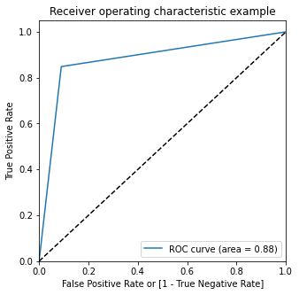

```python
from sklearn import metrics
draw_roc( Y_test, dt_best.predict(X_test) )
```

### Random Forest Classifier

```python
from sklearn.ensemble import RandomForestClassifier
# we will first run a simple random forest classifier and see the performance
from sklearn import model_selection
# random forest model creation
rfc = RandomForestClassifier()
rfc.fit(X_train,Y_train)
# predictions
rfc_predict = rfc.predict(X_test)
rfc_predict
```

```python
rfc_cv_score = cross_val_score(rfc, X_train, Y_train, cv=10, scoring='recall')
```

```python
print("Confusion Matrix ===")
confusion(Y_test,rfc_predict)
print("=== Classification Report ===")
print(classification_report(Y_test, rfc_predict))
```

```python
rfc = RandomForestClassifier(random_state=42)
```

```python
# number of trees in random forest
n_estimators = range(10, 100, 10)
# number of features at every split
max_features = ['auto', 'sqrt']

# max depth
max_depth = [2, 5, 10]

# create random grid
random_grid = {
 'n_estimators': n_estimators,
 'max_features': max_features,
 'max_depth': max_depth
 }
# Random search of parameters
rfc_random = RandomizedSearchCV(estimator = rfc, param_distributions = random_grid, n_iter = 10, cv = 5, verbose=2, random_state=42, n_jobs = -1,scoring='recall')
# Fit the model
rfc_random.fit(X_train, Y_train)
# print results
print(rfc_random.best_params_)
```

```
Fitting 5 folds for each of 10 candidates, totalling 50 fits
{'n_estimators': 90, 'max_features': 'auto', 'max_depth': 10}
```

```
=== Confusion Matrix ===
```

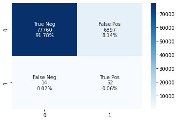

```
=== Classification Report ===
              precision    recall  f1-score   support

           0       1.00      0.92      0.96     84657
           1       0.01      0.79      0.01        66

    accuracy                           0.92     84723
   macro avg       0.50      0.85      0.49     84723
weighted avg       1.00      0.92      0.96     84723



=== All Recall Scores ===
[0.99286184 0.99974687 0.99974689 0.99974689 0.99954437 0.99969625
 0.99969625 0.99984812 0.99964562 0.99989875]


=== Mean Recall Score ===
Mean Recall Score - Random Forest:  0.9990431858767103
```

```python
rfc = RandomForestClassifier(n_estimators=90, max_depth=10, max_features='auto')
rfc.fit(X_train,Y_train)
rfc_predict = rfc.predict(X_test)
print("=== Confusion Matrix ===")
confusion(Y_test, rfc_predict)
print('\n')
print("=== Classification Report ===")
print(classification_report(Y_test, rfc_predict))
print('\n')
print("=== All Recall Scores ===")
print(rfc_cv_score)
print('\n')
print("=== Mean Recall Score ===")
print("Mean Recall Score - Random Forest: ", rfc_cv_score.mean())
```

```python
 draw_roc( Y_test,rfc_predict)
```

### Logistic Classification with and without Lasso/Ridge penalty

#### Logistic regression is a surpervised classification method, which assumes linear relationship between x and y.Lasso tends to do well if there are a small number of significant parameters and the others are close to zero (ergo: when only a few predictors actually influence the response). Ridge works well if there are many large parameters of about the same value (ergo: when most predictors impact the response).

```python
from sklearn.linear_model import LogisticRegression
log = LogisticRegression(penalty='l1', solver='liblinear')
log.fit(X_train, Y_train)
```

```
LogisticRegression(penalty='l1', solver='liblinear')
```

```python
# prediction using simple regression
predictions_simple = log.predict(X_test)
print(predictions_simple)
confusion(Y_test,predictions_simple)
```

[output not shown]

```python
import time
start = time.time()

## now lets check the performance through lasso logistic
from sklearn.linear_model import LogisticRegression
from numpy import arange
from sklearn.model_selection import GridSearchCV

lasso_logistic_model = LogisticRegression(solver='liblinear')

grid = dict()
grid['C'] = np.arange(0.0001, 1, 1)
grid['penalty'] = ['l1', 'l2']# lasso or ridge
search = GridSearchCV(lasso_logistic_model, grid, scoring='recall', cv=10, refit=True)
results = search.fit(X_train, Y_train)

print('Config: %s' % results.best_params_)

end = time.time()
print(end - start)
```

```
Config: {'C': 0.0001, 'penalty': 'l2'}
25.725515127182007
```

```python
# Coeficients of the lasso-logistic model
lasso_model = LogisticRegression(
    penalty='l2',
    solver='liblinear',
    C =  0.0001).fit(X_train,Y_train)

# Coeficients of the traditional logistic model
logistic_model = LogisticRegression(
    penalty='none').fit(X_train,Y_train)
```

```python
# Predictions with the lasso-logistic model
predictions_tuned_model = search.predict(X_test)
print(predictions_tuned_model)

# Predictions with the standard logistic model
logictic_model = LogisticRegression(solver='liblinear').fit(X_train,Y_train)
predictions_non_tuned_model = logictic_model.predict(X_test)
print(predictions_non_tuned_model)
```

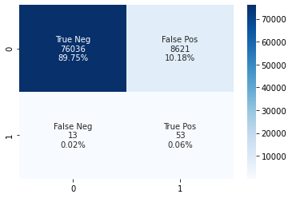

```
=== Classification Report ===
              precision    recall  f1-score   support

           0       1.00      0.90      0.95     84657
           1       0.01      0.80      0.01        66

    accuracy                           0.90     84723
   macro avg       0.50      0.85      0.48     84723
weighted avg       1.00      0.90      0.95     84723
```

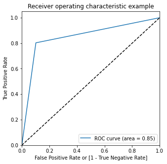

```python
confusion(Y_test,predictions_tuned_model)
print("=== Classification Report ===")
print(classification_report(Y_test,search.predict(X_test)))
draw_roc( Y_test,search.predict(X_test))
```

### XG BOOST CLASSIFICATION

#### The gradient boosted trees algorithm is implemented in XGBoost, a popular and efficient open-source implementation. Gradient boosting is a supervised learning approach that combines the estimates of a set of smaller, weaker models to attempt to accurately predict a target variable. The weak learners in gradient boosting for regression are regression trees, and each regression tree transfers an input data point to one of its leafs containing a continuous score. XGBoost combines a convex loss function (based on the difference between the anticipated and target outputs) with a penalty term for model complexity to minimise a regularised (L1 and L2) objective function (in other words, the regression tree functions). The training process is repeated iteratively, with new trees being added that forecast the residuals or errors of previous trees, which are then integrated with previous trees to provide the final prediction. Gradient boosting gets its name from the fact that it employs a gradient descent algorithm.

```python
#!pip install xgboost
```

```python
model = XGBClassifier()
# fit the model on the whole dataset
model.fit(X_train, Y_train)
```

```python
predictions_xgb_model = model.predict(X_test)
print(predictions_xgb_model)
```

```python
confusion(Y_test,predictions_xgb_model)
print(classification_report(Y_test,predictions_xgb_model))
```

[output not shown]

```
>1 0.960 (0.001)
>2 0.986 (0.002)
>3 0.994 (0.001)
>4 0.999 (0.000)
>5 1.000 (0.000)
>6 1.000 (0.000)
>7 1.000 (0.000)
>8 1.000 (0.000)
>9 0.999 (0.000)
>10 0.999 (0.000)
```

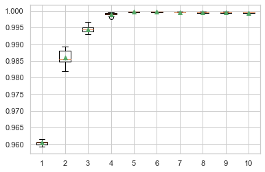

```python
# explore xgboost tree depth effect on performance
# get a list of models to evaluate
def get_models():
    models = dict()
    for i in range(1,11):
        models[str(i)] = XGBClassifier(max_depth=i)
    return models

# evaluate a give model using cross-validation
def evaluate_model(model):
    cv = RepeatedStratifiedKFold(n_splits=4, n_repeats=3, random_state=1)
    scores = cross_val_score(model, X_train, Y_train, scoring='recall', cv=cv, n_jobs=-1)
    return scores

# get the models to evaluate
models = get_models()
# evaluate the models and store results
results, names = list(), list()
for name, model in models.items():
    scores = evaluate_model(model)
    results.append(scores)
    names.append(name)
    print('>%s %.3f (%.3f)' % (name, mean(scores), std(scores)))
# plot model performance for comparison
pyplot.boxplot(results, labels=names, showmeans=True)
pyplot.show()
```

```
>0.0001 0.881 (0.002)
>0.0010 0.884 (0.014)
>0.0100 0.962 (0.001)
>0.1000 0.999 (0.000)
>1.0000 0.808 (0.308)
```

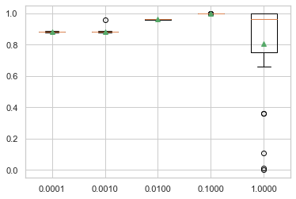

```python
# get a list of learning rates to evaluate
def get_models():
    models = dict()
    rates = [0.0001, 0.001, 0.01, 0.1, 1.0]
    for r in rates:
        key = '%.4f' % r
        models[key] = XGBClassifier(eta=r)
    return models

# evaluate a give model using cross-validation
def evaluate_model(model):
    cv = RepeatedStratifiedKFold(n_splits=10, n_repeats=3, random_state=1)
    scores = cross_val_score(model, X_train, Y_train, scoring='recall', cv=cv, n_jobs=-1)
    return scores

# get the models to evaluate
models = get_models()
# evaluate the models and store results
results, names = list(), list()
for name, model in models.items():
    scores = evaluate_model(model)
    results.append(scores)
    names.append(name)
    print('>%s %.3f (%.3f)' % (name, mean(scores), std(scores)))
# plot model performance for comparison
pyplot.boxplot(results, labels=names, showmeans=True)
pyplot.show()
```

```
>0.1 1.000 (0.000)
>0.2 1.000 (0.000)
>0.3 1.000 (0.000)
>0.4 1.000 (0.000)
>0.5 1.000 (0.000)
>0.6 1.000 (0.000)
>0.7 1.000 (0.000)
>0.8 1.000 (0.000)
>0.9 1.000 (0.000)
>1.0 1.000 (0.000)
```

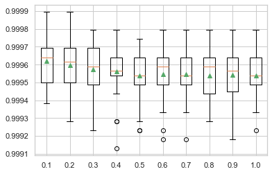

```python
# get a list of models to evaluate
def get_models():
    models = dict()
    for i in arange(0.1, 1.1, 0.1):
        key = '%.1f' % i
        models[key] = XGBClassifier(subsample=i)
    return models

# evaluate a give model using cross-validation
def evaluate_model(model):
    cv = RepeatedStratifiedKFold(n_splits=10, n_repeats=3, random_state=1)
    scores = cross_val_score(model, X_train, Y_train, scoring='recall', cv=cv, n_jobs=-1)
    return scores

# get the models to evaluate
models = get_models()
# evaluate the models and store results
results, names = list(), list()
for name, model in models.items():
    scores = evaluate_model(model)
    results.append(scores)
    names.append(name)
    print('>%s %.3f (%.3f)' % (name, mean(scores), std(scores)))
# plot model performance for comparison
pyplot.boxplot(results, labels=names, showmeans=True)
pyplot.show()
```

```python
xgb_model = XGBClassifier(max_depth=4,learning_rate=0.0001, subsample=0.1)
```

[output not shown]

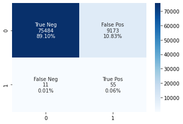

```
=== Classification Report ===
              precision    recall  f1-score   support

           0       1.00      0.89      0.94     84657
           1       0.01      0.83      0.01        66

    accuracy                           0.89     84723
   macro avg       0.50      0.86      0.48     84723
weighted avg       1.00      0.89      0.94     84723
```

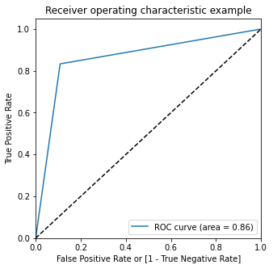

```
27.13985276222229
```

```python
import time
from sklearn import metrics
start = time.time()
xgb_model.fit(X_train,Y_train)
predictions_xgb_model = xgb_model.predict(X_test)
confusion(Y_test,predictions_xgb_model)
print("=== Classification Report ===")
print(classification_report(Y_test,predictions_xgb_model))
draw_roc( Y_test,predictions_xgb_model)
end = time.time()
print(end - start)
```

```python
feature_importance = pd.DataFrame([X_test.columns, xgb_model.feature_importances_]).T
feature_importance.columns = ['Feature', 'Importance']
feature_importance = feature_importance[feature_importance.Importance !=0]
```

```python
plt.figure(figsize=[15,10])
plt.barh(feature_importance.Feature,feature_importance.Importance)
```

[output not shown]

### Support Vector Machines

#### The support vector machine algorithm's goal is to find a hyperplane in an N-dimensional space (N — the number of features) that distinguishes between data points. There are numerous hyperplanes from which to choose to separate the two classes of data points. Our goal is to discover a plane with the greatest margin, or the greatest distance between data points from both classes. Maximizing the margin distance gives some reinforcement, making it easier to classify subsequent data points. Due to computational time limits, CV was not attainable on SVM.

```python
from sklearn.svm import SVC
svm = SVC(gamma='auto')

svm.fit(X_train,Y_train.values.reshape(-1))
prediction = svm.predict(X_test)
print('Accuracy:', accuracy_score(Y_test,prediction))
print('AUC:',roc_auc_score(Y_test,prediction))
```

[output not shown]

```python
print(svm.get_params())
```

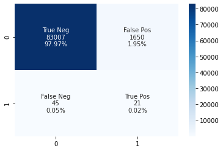

```
              precision    recall  f1-score   support

           0       1.00      0.98      0.99     84657
           1       0.01      0.32      0.02        66

    accuracy                           0.98     84723
   macro avg       0.51      0.65      0.51     84723
weighted avg       1.00      0.98      0.99     84723
```

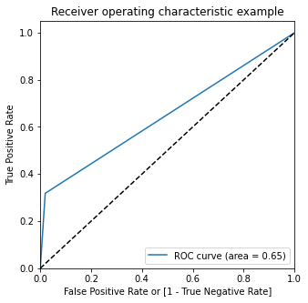

```python
confusion(Y_test,prediction)
print(classification_report(Y_test,prediction))
draw_roc( Y_test,prediction)
```

## ----------------------------------------------------------------------------------------------------------------------------------

# Classification Modeling Techniques (Arrival Delay)

### 1. Neural Network 2.Decision Tree 3. Support Vector Machine 4. XGBoost 5.ADaBoost

```python
df_Delay['Speed'] = df_Delay['Distance']/(df_Delay['AirTime']/60)# creating speed as a variable
```

```python
df_Delay.drop(['Unnamed: 0','Date','Year','DayofMonth','DepDelay','ActualElapsedTime','AirTime','TaxiIn','TaxiOut','CancellationCode','Diverted','CarrierDelay','WeatherDelay','NASDelay','SecurityDelay','LateAircraftDelay','FlightNum','TailNum','DepTime'], axis =1, inplace=True)
```

```python
#df_Delay.ArrDelay = [0 if i<15 else 1 for i in df_Delay.ArrDelay]# converting the data points of arrival delay for target
```

```python
# selecting the top 10 routes which are the busiest in the USA
df_route = df_Delay.groupby(["Origin", "Dest"]).size().reset_index(name="Route").sort_values("Route", ascending=False)
origin_delay = []
dest_delay = []
origin_delay = df_route['Origin'].to_list()
dest_delay = df_route['Dest'].to_list()
origin_delay = origin_delay[:10]
dest_delay = dest_delay[:10]
df_Delay = df_Delay[df_Delay['Origin'].isin (origin_delay)]
df_Delay = df_Delay[df_Delay['Dest'].isin (dest_delay)]
df_Delay.shape
```

```
(77971, 14)
```

```python
df_Delay['ArrDelay'].value_counts()
```

[output not shown]

```python
df_Delay.drop(['CRSElapsedTime','Distance','Cancelled'],axis=1,inplace=True)
```

```python
df_Delay = pd.get_dummies(df_Delay, columns=['Month','Day','UniqueCarrier','Origin','CRSDepTime','CRSArrTime','Dest','ArrTime'],drop_first=True)
```

```python
df_Delay.shape
```

```
(77971, 111)
```

```python
Y = df_Delay['ArrDelay']
X = df_Delay.drop(['ArrDelay'],axis=1)

x_train_delay, x_test_delay, y_train_delay, y_test_delay = train_test_split(X, Y, stratify = Y, test_size = 0.3)
```

```python
ss = MinMaxScaler()
normalized_speed = ss.fit_transform(np.array(x_train_delay['Speed']).reshape(-1, 1))
x_train_delay['Speed'] = normalized_speed
```

```python
x_train_delay.shape
```

```
(54579, 110)
```

```python
normalized_speed = ss.transform(np.array(x_test_delay['Speed']).reshape(-1, 1))
x_test_delay['Speed'] = normalized_speed
```

```python
Y_resampled.value_counts()
```

[output not shown]

```python
oversample = SMOTE()
X_resampled, Y_resampled = oversample.fit_resample(x_train_delay, y_train_delay)
```

```python
X_resampled.shape
```

```
(74376, 110)
```

### Neural Network

```python
from keras.models import Sequential
from keras.layers.core import Dense, Activation

input_dim = X_resampled.shape[1]
output_dim = 1

print('Input dimension: ', input_dim)
print('Output dimension: ', output_dim)
```

```
Input dimension:  110
Output dimension:  1
```

```python
import time
start = time.time()
from tensorflow.keras.optimizers import Adam
model = Sequential()
model.add(Dense(60,input_dim=input_dim))
model.add(Activation('relu'))

model.add(Dense(60))
model.add(Activation('relu'))

model.add(Dense(60))
model.add(Activation('relu'))

model.add(Dense(output_dim))

model.add(Activation('sigmoid'))#sigmoid

model.compile(optimizer=Adam(),loss='binary_crossentropy',metrics=['accuracy'])
model.summary()
model.fit(X_resampled,Y_resampled,epochs=700)
prediction_prob = model.predict(x_test_delay)
prediction_class = (prediction_prob > 0.6).astype("int32")

print('Accuracy:', accuracy_score(y_test_delay,prediction_class))
print('AUC:',roc_auc_score(y_test_delay,prediction_prob))
end = time.time()
print(end - start)
```

[output not shown]

```python
def get_feature_importance(j, n):
    s = accuracy_score(y_test_delay, prediction_class) # baseline score
    total = 0.0
    for i in range(n):
        perm = np.random.permutation(range(x_test_delay.shape[0]))
        X_test_ = x_test_delay.copy()
        X_test_.iloc[:, j] = X_test.iloc[perm, j]
        prediction_prob = model.predict(X_test)
        s_ij = accuracy_score(y_test, prediction_prob)
        total += s_ij
    return s - total / n
```

```python
# Feature importances
f = []
for j in range(x_test_delay.shape[1]):
    f_j = get_feature_importance(j, 10)
    f.append(f_j)
# Plot
plt.figure(figsize=(10, 5))
plt.bar(range(X_test.shape[1]), f, color="r", alpha=0.7)
plt.xticks(ticks=range(X_test.shape[1]))
plt.xlabel("Feature")
plt.ylabel("Importance")
plt.title("Feature importances (Iris data set)")
plt.show()
```

```python
print(classification_report(y_test_delay,prediction_class))
confusion(y_test_delay,prediction_class)
draw_roc( y_test_delay, prediction_class)
```

[output not shown]

## Support Vector Machine

```python
# from sklearn.svm import SVC
from sklearn import svm

#Create a svm Classifier
clf = svm.SVC(kernel='linear', gamma='auto', C=150)

#Train the model using the training sets
clf.fit(X_resampled, Y_resampled)

#svm.fit(x_train,y_train.values.reshape(-1))
prediction = clf.predict(x_test_delay)
print('Accuracy:', accuracy_score(y_test_delay,prediction))
print('AUC:',roc_auc_score(y_test_delay,prediction))
```

```python
confusion(y_test_delay,prediction)
print(classification_report(y_test_delay,prediction))
```

[output not shown]

## Decision Tree

```
Fitting 20 folds for each of 30 candidates, totalling 600 fits
DecisionTreeClassifier(criterion='entropy', max_depth=45, min_samples_leaf=11,
                       random_state=42)
Train Accuracy : 0.8101538130579757
Train Confusion Matrix:
```

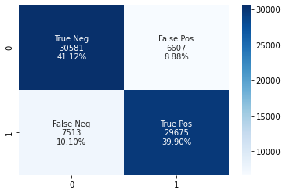

```
AUC: 0.8101538130579757
--------------------------------------------------
Test Accuracy : 0.67390560875513
Test Confusion Matrix:
```

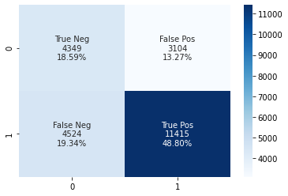

```
AUC: 0.6498456517357571
```

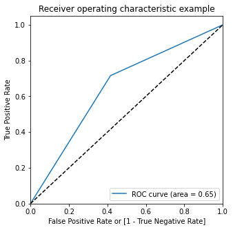

```
              precision    recall  f1-score   support

           0       0.49      0.58      0.53      7453
           1       0.79      0.72      0.75     15939

    accuracy                           0.67     23392
   macro avg       0.64      0.65      0.64     23392
weighted avg       0.69      0.67      0.68     23392

392.87632060050964
```

```python
#Decision Tree for Delay
start = time.time()
dt = DecisionTreeClassifier(random_state=42)
params = {
    'max_depth': [30,40,45],# total depth the tree can grow, smaller the depth lesser the chances of over fitting the data
    'min_samples_leaf': [8,10,11,12,15],# number of segments, each node can be divided into
    'criterion': ["gini", "entropy"]}

grid_search = GridSearchCV(estimator=dt,
                           param_grid=params,
                           cv=20, n_jobs=-1, verbose=1, scoring = "recall")

# we are now performing cross validation
grid_search.fit(X_resampled, Y_resampled)

# the values with the best estimator is achieved through cv
print(grid_search.best_estimator_)

dt_best_delay = grid_search.best_estimator_

# now we will perform the evaluation to test the model on test data
print("Train Accuracy :", accuracy_score(Y_resampled, dt_best_delay.predict(X_resampled)))
print("Train Confusion Matrix:")
confusion(Y_resampled,dt_best_delay.predict(X_resampled))
print('AUC:',roc_auc_score(Y_resampled,dt_best_delay.predict(X_resampled)))
print("-"*50)
print("Test Accuracy :", accuracy_score(y_test_delay, dt_best_delay.predict(x_test_delay)))
print("Test Confusion Matrix:")
confusion(y_test_delay, dt_best_delay.predict(x_test_delay))
print('AUC:',roc_auc_score(y_test_delay,dt_best_delay.predict(x_test_delay)))
draw_roc( y_test_delay, dt_best_delay.predict(x_test_delay) )

print(classification_report(y_test_delay, dt_best_delay.predict(x_test_delay)))
end = time.time()
print(end - start)
```

## XGBOOST

```python
# xgboost
start = time.time()
model_delay = XGBClassifier(max_depth=25,learning_rate=0.0001, subsample=0.8)

model_delay.fit(X_resampled,Y_resampled)
predictions_xgb_delay = model_delay.predict(x_test_delay)
confusion(y_test_delay,predictions_xgb_delay)
print("=== Classification Report ===")
print(classification_report(y_test_delay,predictions_xgb_delay))
draw_roc( y_test_delay,predictions_xgb_delay)
end = time.time()
```

[output not shown]

## ADA Boost

```python
from sklearn.ensemble import AdaBoostClassifier
# Create adaboost classifer object
abc = AdaBoostClassifier(n_estimators=700,learning_rate=0.1,n_samples=1000,
                         n_features=4,n_informative=2, n_redundant=0,random_state=0, shuffle=False)
# Train Adaboost Classifer
model = abc.fit(X_resampled, Y_resampled)

#Predict the response for test dataset
y_pred = model.predict(x_test_delay)
print("Accuracy:",metrics.accuracy_score(y_test_delay, y_pred))
print(classification_report(y_test_delay, y_pred))
```

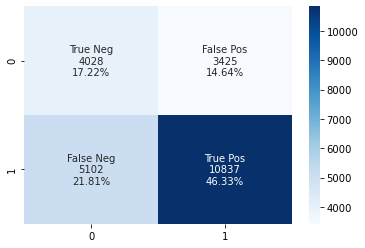

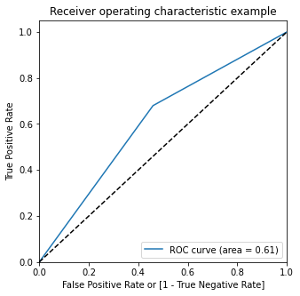

```python
confusion(y_test_delay,y_pred)
draw_roc( y_test_delay,y_pred)
```

```python
from sklearn.ensemble import AdaBoostClassifier
# Create adaboost classifer object
abc = AdaBoostClassifier(n_estimators=700,learning_rate=0.9,algorithm='SAMME.R')
# Train Adaboost Classifer
model = abc.fit(X_resampled, Y_resampled)

#Predict the response for test dataset
y_pred = model.predict(x_test_delay)
print("Accuracy:",metrics.accuracy_score(y_test_delay, y_pred))
print(classification_report(y_test_delay, y_pred))
```

[output not shown]